# Rapport Projet

Elisabeth

2026-01-03

#### **Description du profil sociodémographique des répondants**

Au total, **122 participants** ont pris part à cette enquête. L’âge des participants variait entre **17 et 46 ans, avec un âge médian de 26 ans**. Le groupe d’âge le plus représenté était celui des **15–30 ans, représentant 77,04 % des répondants**.

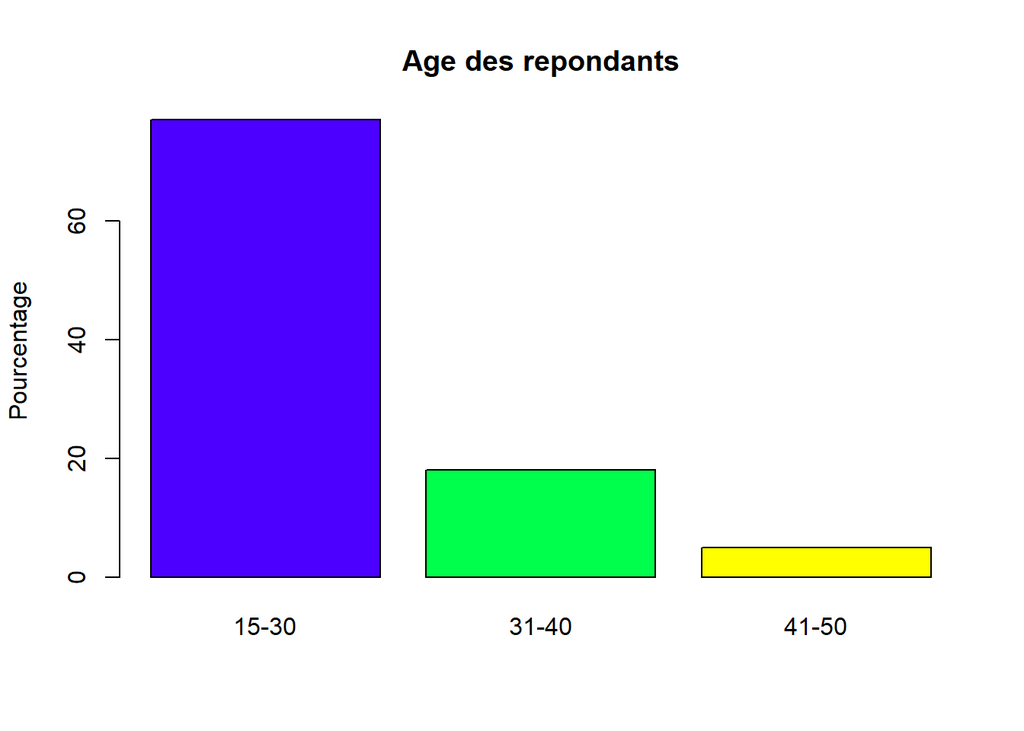

Parmi les 122 répondants, 63,11% sont des femmes et 36,88% sont des hommes.

```
##   class  n prop
## 1 Femme 77 63.1
## 2 Homme 45 36.9
```

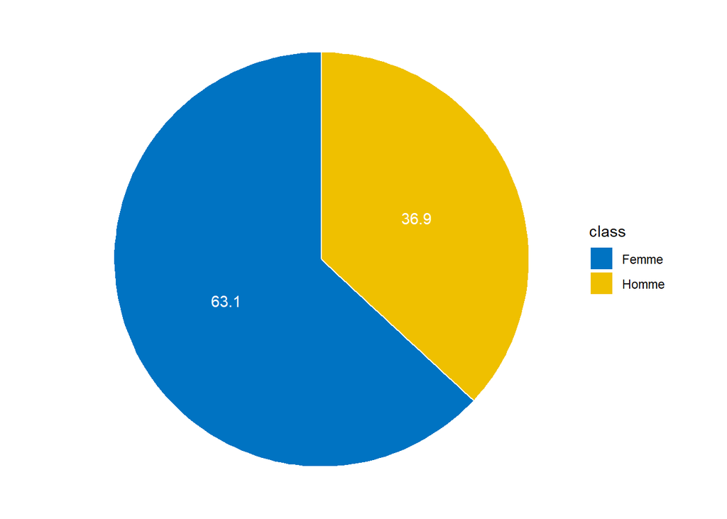

La répartition des répondants selon le pays et la ville de résidence a montré une prédominance nette du Cameroun, qui constituait le pays le plus représenté dans l’étude, ainsi que de la ville de Yaoundé. Au total, **94,26 % des répondants résidaient au Cameroun, contre 4,91 % au Bénin et 0,81 % au Sénégal**.

```
##      class   n prop
## 1 Cameroun 115 94.3
## 2    Benin   6  4.9
## 3  Senegal   1  0.8
```

```
##      class   n prop lab.ypos
## 1  Senegal   1  0.8     0.40
## 2 Cameroun 115 94.3    47.95
## 3    Benin   6  4.9    97.55
```

#### **répartition des répondants par pays**

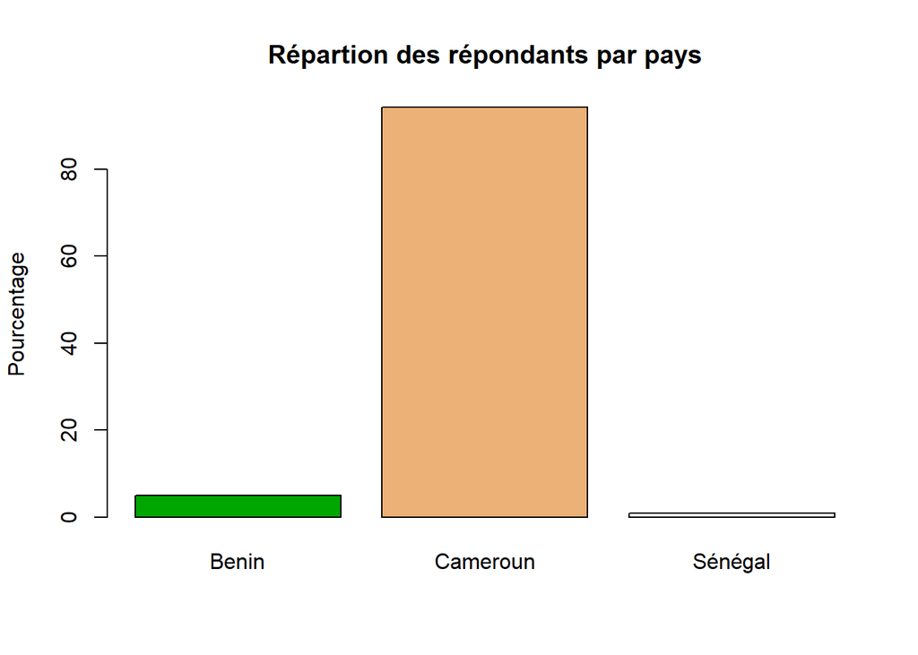

#### **répartition des répondants par ville**

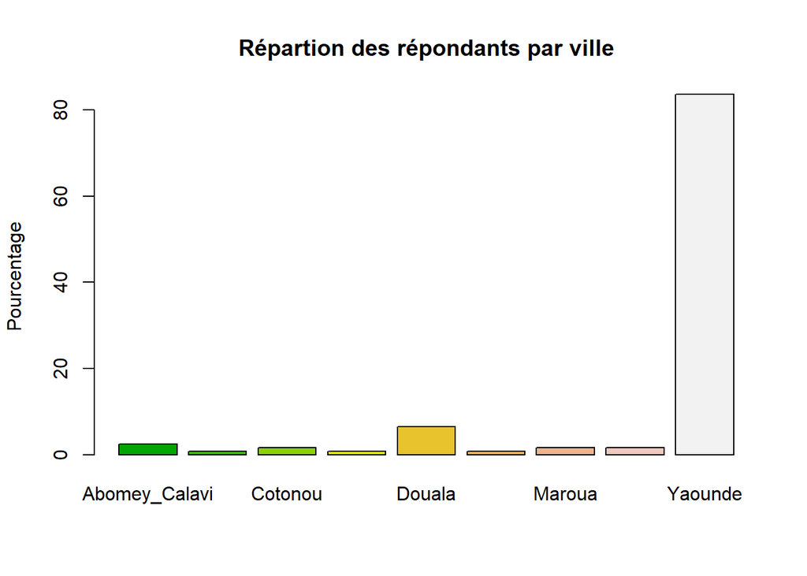

#### **Accès aux technologies numériques**

Concernant l’accès aux technologies, les résultats de l’enquête montrent que l’ensemble des **122 répondants (100 %)** disposent d’un accès à Internet et possèdent un outil de connexion, à savoir un smartphone et/ou un ordinateur portable. Par ailleurs, l’analyse de la fréquence de connexion révèle que **86,9 % des répondants se connectent quotidiennement à Internet**, tandis que **13,1 % déclarent se connecter plusieurs fois par semaine**, mais non tous les jours.

#### **Connaissance du système de ramassage des déchets**

##### **Connaissance des sociétés de collecte**

Parmi les **122 répondants**, **120(98,4 %)** connaissent au moins le nom d’une société de ramassage de déchets dans leur pays, tandis que **2(1,6 %)** déclarent ne pas en connaître.

##### **Connaissance des modalités de ramassage**

Concernant les modalités de ramassage, l’analyse des résultats montre que, parmi les **122 répondants**, **113 individus (92,6 %)** ne connaissent pas les heures de passage des sociétés de ramassage d’ordures, tandis que seulement **9 individus (7,4 %)** déclarent connaître ces horaire.

##### **Analyse des sources d’information**

L’analyse des données sur les sources d’information concernant les horaires de passage des sociétés de ramassage révèle que, parmi les huit sources proposées **(radio, télévision, réseaux sociaux, observation, panneaux d’affichage, site web de la municipalité, bouche à oreille)**, la majorité des répondants obtiennent l’information par le bouche à oreille **(46 individus, 37,7 %)**. D’autres sources sont moins utilisées : **7 individus (5,7 %)** via la télévision, **6 individus (4,7 %)** via la radio, **7 individus (5,7 %)** par observation, **3 individus (2,5 %)** par les panneaux d’affichage et **2 individus (1,6 %)** via le site web de la municipalité.

##### **Utilité perçue de l’application mobile**

Concernant la perception de l’utilité de l’application, sur les **122 répondants**, **99 (81,1 %)** estiment que l’application est utile, tandis que **22 (18,0 %)** considèrent qu’elle ne serait pas utile. Un répondant **(0,8 %)** n’a pas exprimé d’avis.

```
##            Sexe
## Appli_utile F      M      Total
##    Non       63.6%  36.4% 100.0%
##    Oui       63.0%  37.0% 100.0%
##    Ensemble  63.1%  36.9% 100.0%
```

```
##            Age_group
## Appli_utile 15-30  31-40  41-50  Total
##    Non       90.9%   4.5%   4.5% 100.0%
##    Oui       74.0%  21.0%   5.0% 100.0%
##    Ensemble  77.0%  18.0%   4.9% 100.0%
```

Le tableau ci-dessous montre la relation entre l’accès à Internet et la perception de l’utilité de l’application. Les résultats indiquent que **100 % des répondants, quel que soit leur avis sur l’utilité de l’application (utile ou non)**, déclarent avoir accès à Internet.

```
##            acces_internet
## Appli_utile Oui    Total
##    Non      100.0% 100.0%
##    Oui      100.0% 100.0%
##    Ensemble 100.0% 100.0%
```

Le tableau ci-dessous présente la relation entre la disponibilité des outils technologiques et la perception de l’utilité de l’application. Les résultats indiquent que **100 % des répondants, indépendamment de leur appréciation de l’utilité de l’application, disposent d’au moins un outil technologique (smartphone et/ou ordinateur)**.

```
##            outils_technologiques
## Appli_utile Oui    Total
##    Non      100.0% 100.0%
##    Oui      100.0% 100.0%
##    Ensemble 100.0% 100.0%
```

Le tableau ci-dessous présente la relation entre la fréquence de connexion à Internet et la perception de l’utilité de l’application. La majorité des répondants se connectent **tous les jours (86,8 %)**, tandis que **13,2 % déclarent se connecter plusieurs fois par semaine**.

```
##            Frequence_connexion
## Appli_utile plusieurs fois par semaine tous les jours Total
##    Non        4.5%                      95.5%         100.0%
##    Oui       15.0%                      85.0%         100.0%
##    Ensemble  13.1%                      86.9%         100.0%
```

Le tableau ci-dessous présente la relation entre la connaissance des heures de passage des sociétés de ramassage et la perception de l’utilité de l’application. Globalement, la majorité des répondants ne connaissent pas les heures de passage, avec 92,6 % de réponses négatives contre 7,4 % de réponses positives.

```
##            Connaissances_heures_passages
## Appli_utile Non    Oui    Total
##    Non       90.9%   9.1% 100.0%
##    Oui       93.0%   7.0% 100.0%
##    Ensemble  92.6%   7.4% 100.0%
```

#### **Analyse des fonctionnalités souhaitées**

Dans le questionnaire, **cinq fonctionnalités** ont été proposées, notamment :

- **Rappel des heures de collecte**
- **Types de déchets**
- **Conseils de réduction des déchets**
- **Localisation des points de collecte**
- **Signaler les problèmes liés à la collecte**

Pour chaque fonctionnalité, les réponses des participants sont les suivantes :

- **Rappel des heures de collecte** : 113 répondants (**92,6 %**) sont favorables, tandis que **7,4 %** n’ont pas donné d’avis.
- **Types de déchets** : 44,3 % des répondants sont favorables, **55,7 %** n’ont pas donné d’avis.
- **Conseils de réduction des déchets** : 9,8 % des répondants sont favorables, **90,2 %** n’ont pas donné d’avis.
- **Localisation des points de collecte** : 12,3 % des répondants sont favorables, **87,7 %** n’ont pas donné d’avis.
- **Signaler les problèmes liés à la collecte** : aucun répondant n’a donné d’avis (**100 % sans avis**).

#### **% Avis favorable pour la fonction du rappel des heures de collecte**

```
##       n    % val%
## Oui 113 92.6  100
## NA    9  7.4   NA
```

#### **% Avis favorable pour la fonction Type de déchets**

```
##      n    % val%
## Oui 54 44.3  100
## NA  68 55.7   NA
```

#### **% Avis favorable pour la fonction Conseils réduction des déchets**

```
##       n    % val%
## Oui  12  9.8  100
## NA  110 90.2   NA
```

#### **% Avis favorable pour la fonction localisation des points de collecte**

```
##       n    % val%
## Oui  15 12.3  100
## NA  107 87.7   NA
```

#### **Réprésentation graphique des pourcentages de chaque fonctionnalité**

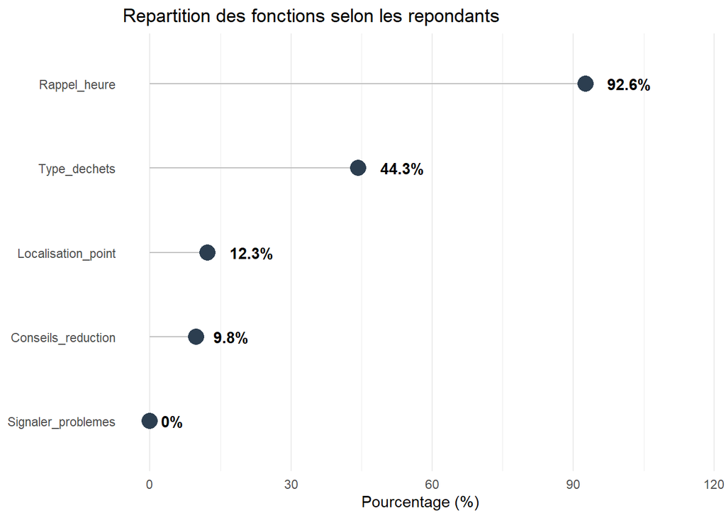

#### **Résultats de la régression multimodale**

La régression logistique multinomiale a été réalisée pour étudier l’effet du sexe et de l’âge sur la perception de l’utilité de l’application (`Appli_utile`). Ces résultats montrent que,

- **Sexe** : pas d’effet (OR = 1,035, p = 0,94).
- **Âge** : les 31-40 ans ont tendance à trouver l’application plus utile que les 15-30 ans (OR = 5,68, p = 0,10), mais ce n’est pas significatif. Les 41-50 ans ne diffèrent pas du groupe de 15-30 ans (OR = 1,35, p = 0,79).
- **Référence (15-30 ans)** : OR = 3,65 (p < 0,001). Nous pouvons donc conclure que le sexe n’a pas d’effet, et l’âge n’influence pas significativement la perception de l’utilité de l’application.

#### **Perception de l’utilité de l’application en fonction du sexe et du groupe d’age**

```
## Call:
## nnet::multinom(formula = Appli_utile ~ Sexe + Age_group, data = data1_reg)
##
## Coefficients:
##                    Values Std. Err.
## (Intercept)    1.29527424 0.3110928
## SexeM          0.03529217 0.4961320
## Age_group31-40 1.73654046 1.0541232
## Age_group41-50 0.30252667 1.1242660
##
## Residual Deviance: 110.8461
## AIC: 118.8461
```

```
##                Odds_Ratio      P_Value
## (Intercept)      3.651997 3.132319e-05
## SexeM            1.035922 9.432906e-01
## Age_group31-40   5.677667 9.948016e-02
## Age_group41-50   1.353274 7.878618e-01
```

#### **Regression logistique perception de l’utilité de l’appli en fonction de la fréquence de connexion, connaissances des heures de passages et de ramassage des sociétés**

Afin d’évaluer l’effet de la connaissance de la société de ramassage, de la connaissance des horaires de passage et de la fréquence de connexion sur la perception de l’utilité de l’application (`Appli_utile`), une régression multinomiale a été réalisée.

Les résultats indiquent qu’aucune des variables étudiées n’a d’effet statistiquement significatif sur la perception de l’utilité de l’application. Ni la connaissance de la société de ramassage (odds ratio = 4,28, p = 0,31), ni la connaissance des horaires de passage (odds ratio = 0,82, p = 0,81), ni la fréquence de connexion quotidienne (odds ratio = 0,29, p = 0,24) n’influencent significativement cette perception.

Ainsi, aucun des facteurs analysés ne semble déterminer de manière significative l’utilité perçue de l’application.

```
## Call:
## nnet::multinom(formula = Appli_utile ~ connaissance_societe_ramassage +
##     Connaissances_heures_passages + Frequence_connexion, data = data3_reg)
##
## Coefficients:
##                                       Values Std. Err.
## (Intercept)                        1.2546186 1.7706502
## connaissance_societe_ramassageOui  1.4534238 1.4382429
## Connaissances_heures_passagesOui  -0.2006548 0.8434489
## Frequence_connexiontous les jours -1.2546070 1.0654586
##
## Residual Deviance: 112.0258
## AIC: 120.0258
```

```
##                                   Odds_Ratio   P_Value
## (Intercept)                        3.5065006 0.4785952
## connaissance_societe_ramassageOui  4.2777354 0.3122294
## Connaissances_heures_passagesOui   0.8181948 0.8119602
## Frequence_connexiontous les jours  0.2851879 0.2389850
```

#### **Association Apllication utile et l’age**

**H0** : Il n’y a aucune association entre l’âge et la perception de l’utilité

**H1** : Il existe une association

Pour déterminer s’il existe une association entre les groupes d’âge et la perception de l’utilité de l’application.Un test exact de Fisher a été réalisé le résultat de ce test montre qu’il n’existe aucune association entre la perception de l’utilité de l’application et l’age (p-value = 0,184).

```
##
##  Fisher's Exact Test for Count Data
##
## data:  table(data1$Appli_utile, data1$Age_group)
## p-value = 0.1837
## alternative hypothesis: two.sided
```

[output not shown]